# Titanic Data Analysis

### Introduction:

The aim of this project is to analysis sample of Titanic data set and find out if the factor "being a mother with children onboard" played favor for them, in increasing number of survives among them(mothers).

Also, through this project, another question will be answered which is does the Class factor helped those who were in upper class to survive more than those who were in lowest class in Titanic.

### Data Wrangling:

#### import libraries:

```python
import numpy as np
import pandas as pd
import csv
import matplotlib.pyplot as plt; plt.rcdefaults()
```

#### Load data:

Loading data in csv file into DataFrame using Panda. Then show only first 10 rows  
[Resource](https://chrisalbon.com/python/pandas_dataframe_importing_csv.html)

```python
df=pd.read_csv("titanic-data.csv")
df.head(10)
```

|  | PassengerId | Survived | Pclass | Name | Sex | Age | SibSp | Parch | Ticket | Fare | Cabin | Embarked |
| --- | --- | --- | --- | --- | --- | --- | --- | --- | --- | --- | --- | --- |
| 0 | 1 | 0 | 3 | Braund, Mr. Owen Harris | male | 22.0 | 1 | 0 | A/5 21171 | 7.2500 | NaN | S |
| 1 | 2 | 1 | 1 | Cumings, Mrs. John Bradley (Florence Briggs Th... | female | 38.0 | 1 | 0 | PC 17599 | 71.2833 | C85 | C |
| 2 | 3 | 1 | 3 | Heikkinen, Miss. Laina | female | 26.0 | 0 | 0 | STON/O2. 3101282 | 7.9250 | NaN | S |
| 3 | 4 | 1 | 1 | Futrelle, Mrs. Jacques Heath (Lily May Peel) | female | 35.0 | 1 | 0 | 113803 | 53.1000 | C123 | S |
| 4 | 5 | 0 | 3 | Allen, Mr. William Henry | male | 35.0 | 0 | 0 | 373450 | 8.0500 | NaN | S |
| 5 | 6 | 0 | 3 | Moran, Mr. James | male | NaN | 0 | 0 | 330877 | 8.4583 | NaN | Q |
| 6 | 7 | 0 | 1 | McCarthy, Mr. Timothy J | male | 54.0 | 0 | 0 | 17463 | 51.8625 | E46 | S |
| 7 | 8 | 0 | 3 | Palsson, Master. Gosta Leonard | male | 2.0 | 3 | 1 | 349909 | 21.0750 | NaN | S |
| 8 | 9 | 1 | 3 | Johnson, Mrs. Oscar W (Elisabeth Vilhelmina Berg) | female | 27.0 | 0 | 2 | 347742 | 11.1333 | NaN | S |
| 9 | 10 | 1 | 2 | Nasser, Mrs. Nicholas (Adele Achem) | female | 14.0 | 1 | 0 | 237736 | 30.0708 | NaN | C |

Number of rows and number of columns:

```python
df.shape
```

```
(891, 12)
```

Data type of each column:

```python
df.dtypes
```

```
PassengerId      int64
Survived         int64
Pclass           int64
Name            object
Sex             object
Age            float64
SibSp            int64
Parch            int64
Ticket          object
Fare           float64
Cabin           object
Embarked        object
dtype: object
```

Change type of Survived column from int to boolean:

```python
df[['Survived']] = df[['Survived']].astype(bool)
```

To solve my two questions I'll focus on follwoing data:

- Survived
- Pclass
- Sex
- Age
- SibSp
- Parch

If any one of them has null record, I'll delete rows that has null in order to not affect results laster.  
Resource

```python
pd.isnull(df).any()
```

```
PassengerId    False
Survived       False
Pclass         False
Name           False
Sex            False
Age             True
SibSp          False
Parch          False
Ticket         False
Fare           False
Cabin           True
Embarked        True
dtype: bool
```

```python
df['Age'].unique() #Range of ages dataset
```

```
array([ 22.  ,  38.  ,  26.  ,  35.  ,    nan,  54.  ,   2.  ,  27.  ,
        14.  ,   4.  ,  58.  ,  20.  ,  39.  ,  55.  ,  31.  ,  34.  ,
        15.  ,  28.  ,   8.  ,  19.  ,  40.  ,  66.  ,  42.  ,  21.  ,
        18.  ,   3.  ,   7.  ,  49.  ,  29.  ,  65.  ,  28.5 ,   5.  ,
        11.  ,  45.  ,  17.  ,  32.  ,  16.  ,  25.  ,   0.83,  30.  ,
        33.  ,  23.  ,  24.  ,  46.  ,  59.  ,  71.  ,  37.  ,  47.  ,
        14.5 ,  70.5 ,  32.5 ,  12.  ,   9.  ,  36.5 ,  51.  ,  55.5 ,
        40.5 ,  44.  ,   1.  ,  61.  ,  56.  ,  50.  ,  36.  ,  45.5 ,
        20.5 ,  62.  ,  41.  ,  52.  ,  63.  ,  23.5 ,   0.92,  43.  ,
        60.  ,  10.  ,  64.  ,  13.  ,  48.  ,   0.75,  53.  ,  57.  ,
        80.  ,  70.  ,  24.5 ,   6.  ,   0.67,  30.5 ,   0.42,  34.5 ,  74.  ])
```

Remove Null values from **Age** column.  
[Resource](https://stackoverflow.com/questions/14991195/how-to-remove-rows-with-null-values-from-kth-column-onward-in-python)

```python
df=df.dropna(subset=['Age'])
```

The original data set had **891 records**, that means **177 records** has Null value in **Age** column.

```python
df['PassengerId'].count()
```

```
714
```

```python
df['Age'].unique() #Range of ages dataset
```

```
array([ 22.  ,  38.  ,  26.  ,  35.  ,  54.  ,   2.  ,  27.  ,  14.  ,
         4.  ,  58.  ,  20.  ,  39.  ,  55.  ,  31.  ,  34.  ,  15.  ,
        28.  ,   8.  ,  19.  ,  40.  ,  66.  ,  42.  ,  21.  ,  18.  ,
         3.  ,   7.  ,  49.  ,  29.  ,  65.  ,  28.5 ,   5.  ,  11.  ,
        45.  ,  17.  ,  32.  ,  16.  ,  25.  ,   0.83,  30.  ,  33.  ,
        23.  ,  24.  ,  46.  ,  59.  ,  71.  ,  37.  ,  47.  ,  14.5 ,
        70.5 ,  32.5 ,  12.  ,   9.  ,  36.5 ,  51.  ,  55.5 ,  40.5 ,
        44.  ,   1.  ,  61.  ,  56.  ,  50.  ,  36.  ,  45.5 ,  20.5 ,
        62.  ,  41.  ,  52.  ,  63.  ,  23.5 ,   0.92,  43.  ,  60.  ,
        10.  ,  64.  ,  13.  ,  48.  ,   0.75,  53.  ,  57.  ,  80.  ,
        70.  ,  24.5 ,   6.  ,   0.67,  30.5 ,   0.42,  34.5 ,  74.  ])
```

### Data Exploring:

#### Female vs Male

Persntage of female passengers vs male passengers:  
[Resource 1](https://stackoverflow.com/questions/43549901/visualize-data-from-one-column) [Resource 2](https://stackoverflow.com/questions/6170246/how-do-i-use-matplotlib-autopct) [Resource 3](https://stackoverflow.com/questions/29786807/how-to-make-a-pie-chart-smaller-with-matplotlib)

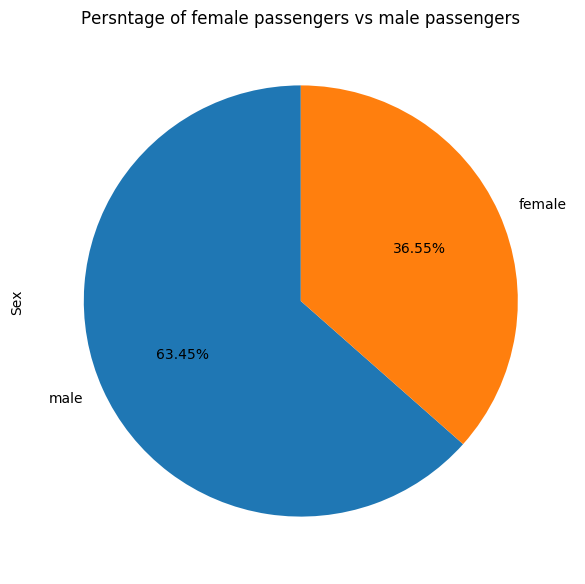

```python
df["Sex"].value_counts().plot.pie(autopct='%.2f%%', startangle=90)
figure = plt.gcf()
figure.set_size_inches(7,7)
plt.title('Persntage of female passengers vs male passengers')
plt.show()
```

From figure above, it shows that almost **64%** of passengers were **male**.****

#### Surviving vs didn't survive (male vs female)

```python
SurvivedFemalePassengers=df[(df.Sex=="female") & (df['Survived']==True)]
NotSurvivedFemalePassengers=df[(df.Sex=="female") & (df['Survived']==False)]

SurvivedMalePassengers=df[(df.Sex!="female") & (df['Survived']==True)]
NotSurvivedMalePassengers=df[(df.Sex!="female") & (df['Survived']==False)]
```

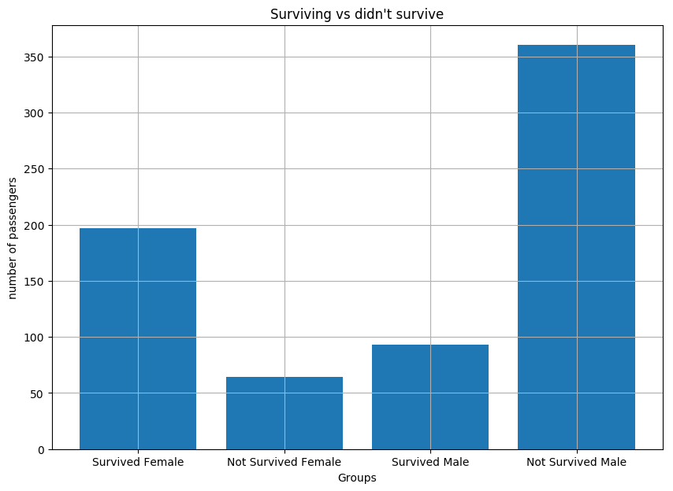

```python
obj = ('Survived Female', 'Not Survived Female', 'Survived Male', 'Not Survived Male')
y = np.arange(len(obj))
count = [SurvivedFemalePassengers.PassengerId.count(),NotSurvivedFemalePassengers.PassengerId.count(),SurvivedMalePassengers.PassengerId.count(),NotSurvivedMalePassengers.PassengerId.count()]
plt.bar(y, count, align='center')
plt.xticks(y, obj)
plt.ylabel('number of passengers')
plt.xlabel('Groups')
plt.title('Surviving vs didn\'t survive')
figure = plt.gcf()
figure.set_size_inches(10,7)
plt.grid()
plt.show()
```

From figure above, majority of men died while majority of women survived, there are many possible reasons behind that:

- It might be women were given **priority** in rescuing
- It might be different in classes and great number of men were from **3rd class** as it was the farthest place from emergency boats

#### Surviving rate among classes:

Classes:

```python
FirstClass=df[df.Pclass==1]
SecondClass=df[df.Pclass==2]
ThirdClass=df[df.Pclass==3]
```

##### Survived in each class based on gender

1st class:

```python
FemaleSurvivedFirstClass=FirstClass[(FirstClass.Sex=="female") & (FirstClass['Survived']==True)]
FemaleDidntSurviveFirstClass=FirstClass[(FirstClass.Sex=="female") & (FirstClass['Survived']!=True)]

MaleSurvivedFirstClass=FirstClass[(FirstClass.Sex!="female") & (FirstClass['Survived']==True)]
MaleDidntSurviveFirstClass=FirstClass[(FirstClass.Sex!="female") & (FirstClass['Survived']!=True)]
```

2nd class:

```python
FemaleSurvivedSecondClass=SecondClass[(SecondClass.Sex=="female") & (SecondClass['Survived']==True)]
FemaleDidntSurviveSecondClass=SecondClass[(SecondClass.Sex=="female") & (SecondClass['Survived']!=True)]

MaleSurvivedSecondClass=SecondClass[(SecondClass.Sex!="female") & (SecondClass['Survived']==True)]
MaleDidntSurviveSecondClass=SecondClass[(SecondClass.Sex!="female") & (SecondClass['Survived']!=True)]
```

3rd class:

```python
FemaleSurvivedThirdClass=ThirdClass[(ThirdClass.Sex=="female") & (ThirdClass['Survived']==True)]
FemaleDidntSurviveThirdClass=ThirdClass[(ThirdClass.Sex=="female") & (ThirdClass['Survived']!=True)]

MaleSurvivedThirdClass=ThirdClass[(ThirdClass.Sex!="female") & (ThirdClass['Survived']==True)]
MaleDidntSurviveThirdClass=ThirdClass[(ThirdClass.Sex!="female") & (ThirdClass['Survived']!=True)]
```

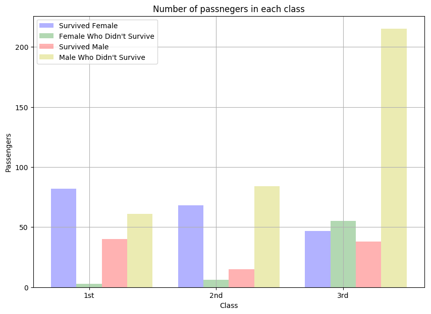

```python
n_groups = 3
SurvivedFemaleBar = (FemaleSurvivedFirstClass.PassengerId.count(), FemaleSurvivedSecondClass.PassengerId.count(),
                     FemaleSurvivedThirdClass.PassengerId.count())

FemaleDidntSurviveBar = (FemaleDidntSurviveFirstClass.PassengerId.count(), FemaleDidntSurviveSecondClass.PassengerId.count(),
                         FemaleDidntSurviveThirdClass.PassengerId.count())

SurvivedMaleBar = (MaleSurvivedFirstClass.PassengerId.count(), MaleSurvivedSecondClass.PassengerId.count(),
                    MaleSurvivedThirdClass.PassengerId.count())


MaleDidntSurviveBar = (MaleDidntSurviveFirstClass.PassengerId.count(), MaleDidntSurviveSecondClass.PassengerId.count(),
                       MaleDidntSurviveThirdClass.PassengerId.count())

# create plot
fig, ax = plt.subplots()
index = np.arange(n_groups)
bar_width = 0.2
opacity =0.3

rects1 = plt.bar(index, SurvivedFemaleBar, bar_width,
                 alpha=opacity,
                 color='b',
                 label='Survived Female')


rects2 = plt.bar(index + bar_width, FemaleDidntSurviveBar, bar_width,
                 alpha=opacity,
                 color='g',
                 label='Female Who Didn\'t Survive')

rects3 = plt.bar(index + 2*bar_width, SurvivedMaleBar, bar_width,
                 alpha=opacity,
                 color='r',
                 label='Survived Male')

rects4 = plt.bar(index + 3*bar_width, MaleDidntSurviveBar, bar_width,
                 alpha=opacity,
                 color='y',
                 label='Male Who Didn\'t Survive')

plt.xlabel('Class')
plt.ylabel('Passengers')
plt.title('Number of passnegers in each class')
plt.xticks(index + bar_width, ('1st', '2nd', '3rd'))

plt.legend()
plt.grid()

figure = plt.gcf()
figure.set_size_inches(10,7)

plt.show()
```

chart above shows that indeed ticket class of passenger palyed big rule on his/her surviving chance. If we look at Titanic Deckplans [here](https://www.encyclopedia-titanica.org/titanic-deckplans/) we can notice that first class places is locate in middle of ship which was close to emergency boats, unlike third class which was the farest.  
[Resource](https://pythonspot.com/en/matplotlib-bar-chart/)

#### Mother vs Not-mother:

###### Understanding Parch variable

So far it's not clear to me what does **Parch** variable number mean, in explanation it says **Parch** cover the family relationship: Mother,Father,Daughter, Son, Stepdaughter, and Stepson....but how it actually count when conducting the data. For investagtion purpose, I will work with the main DataFrame which is df.  
In order to understand something it's better to start with its extreme case :)

```python
df.loc[df.Parch==df["Parch"].max()]
```

|  | PassengerId | Survived | Pclass | Name | Sex | Age | SibSp | Parch | Ticket | Fare | Cabin | Embarked |
| --- | --- | --- | --- | --- | --- | --- | --- | --- | --- | --- | --- | --- |
| 678 | 679 | False | 3 | Goodwin, Mrs. Frederick (Augusta Tyler) | female | 43.0 | 1 | 6 | CA 2144 | 46.9 | NaN | S |

From previous code I was able to find the row with largest number in **Parch** column. Here I filter DataFrame for any person whose name has **Goodwin** name in it assuming she/he part of **Goodwin** family and related to **Mrs.Goodwin**  
[Resource](https://stackoverflow.com/questions/27975069/how-to-filter-rows-containing-a-string-pattern-from-a-pandas-dataframe)

```python
df[df['Name'].str.contains("Goodwin")]
```

|  | PassengerId | Survived | Pclass | Name | Sex | Age | SibSp | Parch | Ticket | Fare | Cabin | Embarked |
| --- | --- | --- | --- | --- | --- | --- | --- | --- | --- | --- | --- | --- |
| 59 | 60 | False | 3 | Goodwin, Master. William Frederick | male | 11.0 | 5 | 2 | CA 2144 | 46.9 | NaN | S |
| 71 | 72 | False | 3 | Goodwin, Miss. Lillian Amy | female | 16.0 | 5 | 2 | CA 2144 | 46.9 | NaN | S |
| 386 | 387 | False | 3 | Goodwin, Master. Sidney Leonard | male | 1.0 | 5 | 2 | CA 2144 | 46.9 | NaN | S |
| 480 | 481 | False | 3 | Goodwin, Master. Harold Victor | male | 9.0 | 5 | 2 | CA 2144 | 46.9 | NaN | S |
| 678 | 679 | False | 3 | Goodwin, Mrs. Frederick (Augusta Tyler) | female | 43.0 | 1 | 6 | CA 2144 | 46.9 | NaN | S |
| 683 | 684 | False | 3 | Goodwin, Mr. Charles Edward | male | 14.0 | 5 | 2 | CA 2144 | 46.9 | NaN | S |

```python
df[df.Ticket=="CA 2144"]
```

|  | PassengerId | Survived | Pclass | Name | Sex | Age | SibSp | Parch | Ticket | Fare | Cabin | Embarked |
| --- | --- | --- | --- | --- | --- | --- | --- | --- | --- | --- | --- | --- |
| 59 | 60 | False | 3 | Goodwin, Master. William Frederick | male | 11.0 | 5 | 2 | CA 2144 | 46.9 | NaN | S |
| 71 | 72 | False | 3 | Goodwin, Miss. Lillian Amy | female | 16.0 | 5 | 2 | CA 2144 | 46.9 | NaN | S |
| 386 | 387 | False | 3 | Goodwin, Master. Sidney Leonard | male | 1.0 | 5 | 2 | CA 2144 | 46.9 | NaN | S |
| 480 | 481 | False | 3 | Goodwin, Master. Harold Victor | male | 9.0 | 5 | 2 | CA 2144 | 46.9 | NaN | S |
| 678 | 679 | False | 3 | Goodwin, Mrs. Frederick (Augusta Tyler) | female | 43.0 | 1 | 6 | CA 2144 | 46.9 | NaN | S |
| 683 | 684 | False | 3 | Goodwin, Mr. Charles Edward | male | 14.0 | 5 | 2 | CA 2144 | 46.9 | NaN | S |

The first thing I notice from above result is that they all have the same **Ticket number**, I checked if other passengers has the same **Ticket number** and it shows only **Goodwin** family has it. The second thing I noticed is **Age**, **5** out of **6** people are under **20** and only **Mrs. Goodwin** is **43**, that means the **Goodwin** family was a mother</b> and **5** of her children.

Each child has value **2** in **Parch** column, and we know so far that the child has a mother which is **Mrs. Goodwin**, that means their father was on board but not in this list!

Also, it's important to notice that in **SibSp** column it count each child + her/his siblings!

**Mrs. Goodwin** has value **6** in **Parch** column and we already knew that she had **5** children that mean the remaining **1** is her husband.

So far, to know if **female** is indeed a **mother**, she should have at least **1** on **Parch** and **Mrs.** word in her name but because a passenger might be a **mother** but with no husband **"Single mother"**.

```python
df.iloc[df["SibSp"].argmax()]
```

```
PassengerId                               79
Survived                                True
Pclass                                     2
Name           Caldwell, Master. Alden Gates
Sex                                     male
Age                                     0.83
SibSp                                      0
Parch                                      2
Ticket                                248738
Fare                                      29
Cabin                                    NaN
Embarked                                   S
Name: 78, dtype: object
```

To study more about **Parch** column I need more extreme value. [Resource](https://www.dataquest.io/blog/pandas-cheat-sheet/)

```python
df.sort_values("Parch",ascending=False).head(5)
```

|  | PassengerId | Survived | Pclass | Name | Sex | Age | SibSp | Parch | Ticket | Fare | Cabin | Embarked |
| --- | --- | --- | --- | --- | --- | --- | --- | --- | --- | --- | --- | --- |
| 678 | 679 | False | 3 | Goodwin, Mrs. Frederick (Augusta Tyler) | female | 43.0 | 1 | 6 | CA 2144 | 46.9000 | NaN | S |
| 885 | 886 | False | 3 | Rice, Mrs. William (Margaret Norton) | female | 39.0 | 0 | 5 | 382652 | 29.1250 | NaN | Q |
| 25 | 26 | True | 3 | Asplund, Mrs. Carl Oscar (Selma Augusta Emilia... | female | 38.0 | 1 | 5 | 347077 | 31.3875 | NaN | S |
| 610 | 611 | False | 3 | Andersson, Mrs. Anders Johan (Alfrida Konstant... | female | 39.0 | 1 | 5 | 347082 | 31.2750 | NaN | S |
| 638 | 639 | False | 3 | Panula, Mrs. Juha (Maria Emilia Ojala) | female | 41.0 | 0 | 5 | 3101295 | 39.6875 | NaN | S |

Search for **Panula** family

```python
df[df['Name'].str.contains("Panula")]
```

|  | PassengerId | Survived | Pclass | Name | Sex | Age | SibSp | Parch | Ticket | Fare | Cabin | Embarked |
| --- | --- | --- | --- | --- | --- | --- | --- | --- | --- | --- | --- | --- |
| 50 | 51 | False | 3 | Panula, Master. Juha Niilo | male | 7.0 | 4 | 1 | 3101295 | 39.6875 | NaN | S |
| 164 | 165 | False | 3 | Panula, Master. Eino Viljami | male | 1.0 | 4 | 1 | 3101295 | 39.6875 | NaN | S |
| 266 | 267 | False | 3 | Panula, Mr. Ernesti Arvid | male | 16.0 | 4 | 1 | 3101295 | 39.6875 | NaN | S |
| 638 | 639 | False | 3 | Panula, Mrs. Juha (Maria Emilia Ojala) | female | 41.0 | 0 | 5 | 3101295 | 39.6875 | NaN | S |
| 686 | 687 | False | 3 | Panula, Mr. Jaako Arnold | male | 14.0 | 4 | 1 | 3101295 | 39.6875 | NaN | S |
| 824 | 825 | False | 3 | Panula, Master. Urho Abraham | male | 2.0 | 4 | 1 | 3101295 | 39.6875 | NaN | S |

Search for **Andersson**

```python
df[df['Name'].str.contains("Andersson")]
```

|  | PassengerId | Survived | Pclass | Name | Sex | Age | SibSp | Parch | Ticket | Fare | Cabin | Embarked |
| --- | --- | --- | --- | --- | --- | --- | --- | --- | --- | --- | --- | --- |
| 13 | 14 | False | 3 | Andersson, Mr. Anders Johan | male | 39.0 | 1 | 5 | 347082 | 31.2750 | NaN | S |
| 68 | 69 | True | 3 | Andersson, Miss. Erna Alexandra | female | 17.0 | 4 | 2 | 3101281 | 7.9250 | NaN | S |
| 119 | 120 | False | 3 | Andersson, Miss. Ellis Anna Maria | female | 2.0 | 4 | 2 | 347082 | 31.2750 | NaN | S |
| 146 | 147 | True | 3 | Andersson, Mr. August Edvard ("Wennerstrom") | male | 27.0 | 0 | 0 | 350043 | 7.7958 | NaN | S |
| 541 | 542 | False | 3 | Andersson, Miss. Ingeborg Constanzia | female | 9.0 | 4 | 2 | 347082 | 31.2750 | NaN | S |
| 542 | 543 | False | 3 | Andersson, Miss. Sigrid Elisabeth | female | 11.0 | 4 | 2 | 347082 | 31.2750 | NaN | S |
| 610 | 611 | False | 3 | Andersson, Mrs. Anders Johan (Alfrida Konstant... | female | 39.0 | 1 | 5 | 347082 | 31.2750 | NaN | S |
| 813 | 814 | False | 3 | Andersson, Miss. Ebba Iris Alfrida | female | 6.0 | 4 | 2 | 347082 | 31.2750 | NaN | S |
| 850 | 851 | False | 3 | Andersson, Master. Sigvard Harald Elias | male | 4.0 | 4 | 2 | 347082 | 31.2750 | NaN | S |

The list above shows more data than what I expected, means there were pasnegers with same family name, to filter only **Mrs. Anders Johan Andersson** family I will filter results based on **ticket number** becuase so far I noticed that each family memebr share the same **ticket number.** [Resoucre](https://www.dataquest.io/blog/pandas-cheat-sheet/)

```python
AnderssonFamily=df[(df['Name'].str.contains("Andersson"))& (df['Ticket'].str.contains('347082'))]
AnderssonFamily
```

|  | PassengerId | Survived | Pclass | Name | Sex | Age | SibSp | Parch | Ticket | Fare | Cabin | Embarked |
| --- | --- | --- | --- | --- | --- | --- | --- | --- | --- | --- | --- | --- |
| 13 | 14 | False | 3 | Andersson, Mr. Anders Johan | male | 39.0 | 1 | 5 | 347082 | 31.275 | NaN | S |
| 119 | 120 | False | 3 | Andersson, Miss. Ellis Anna Maria | female | 2.0 | 4 | 2 | 347082 | 31.275 | NaN | S |
| 541 | 542 | False | 3 | Andersson, Miss. Ingeborg Constanzia | female | 9.0 | 4 | 2 | 347082 | 31.275 | NaN | S |
| 542 | 543 | False | 3 | Andersson, Miss. Sigrid Elisabeth | female | 11.0 | 4 | 2 | 347082 | 31.275 | NaN | S |
| 610 | 611 | False | 3 | Andersson, Mrs. Anders Johan (Alfrida Konstant... | female | 39.0 | 1 | 5 | 347082 | 31.275 | NaN | S |
| 813 | 814 | False | 3 | Andersson, Miss. Ebba Iris Alfrida | female | 6.0 | 4 | 2 | 347082 | 31.275 | NaN | S |
| 850 | 851 | False | 3 | Andersson, Master. Sigvard Harald Elias | male | 4.0 | 4 | 2 | 347082 | 31.275 | NaN | S |

Information on **Andersson** family helped me to clarify the confusion I had :)

**Andersson** family has: **Mother**, **Father** and **5** children, so **Mrs. Andersson** had a **husband** and **5** children.

*Conclusion:*  
Mrs word + Parch has value 1 or more indeacte that the passenger was indeed a mother.

Total number of passengers:

```python
TotalCountOfPassengers=df["PassengerId"].count()
TotalCountOfPassengers
```

```
714
```

```python
df.Survived.value_counts()
```

```
False    424
True     290
Name: Survived, dtype: int64
```

```python
290/891.0*100
```

```
32.547699214365885
```